# University of Oregon Running Game

##### Rushing Attack by Stadium

Oregon Running Game by Venue

| venue | mean_epa | success_rate | ypc | plays |
| --- | --- | --- | --- | --- |
| Autzen Stadium | 0.12 | 0.47 | 6.37 | 2875 |
| Reser Stadium | 0.20 | 0.49 | 6.67 | 269 |
| Husky Stadium | 0.03 | 0.47 | 4.93 | 227 |
| California Memorial Stadium | -0.01 | 0.44 | 4.55 | 218 |
| Los Angeles Memorial Coliseum | 0.11 | 0.50 | 5.86 | 204 |
| Sun Devil Stadium | 0.03 | 0.38 | 6.05 | 173 |
| Folsom Field | 0.16 | 0.52 | 6.64 | 165 |
| Martin Stadium | 0.16 | 0.49 | 6.56 | 165 |
| Stanford Stadium | 0.03 | 0.41 | 5.78 | 164 |
| Levi’s Stadium | 0.09 | 0.45 | 6.12 | 139 |
| Rose Bowl | 0.07 | 0.46 | 6.42 | 138 |
| Rice-Eccles Stadium | 0.06 | 0.38 | 6.07 | 114 |
| Arizona Stadium | 0.13 | 0.48 | 6.35 | 109 |
| War Memorial Stadium | 0.07 | 0.49 | 4.83 | 63 |

#### Rushing Effectiveness by Down

Data on 1st & 2nd down is much more predictably given the R^2 is above 0.5. That being said Oregon was much more efficient running on 1st down then on 2nd down with the a higher amount of yards gained per EPA.

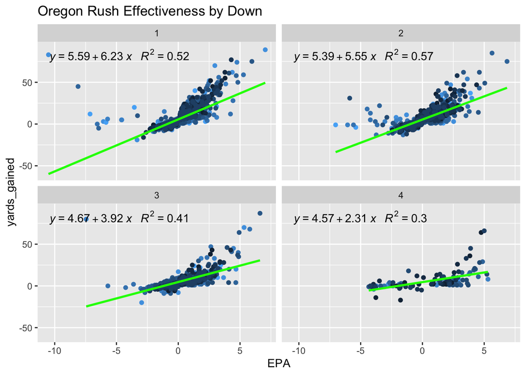

#### Oregon Rushing on 1st Down

Oregon rushing on 1st down hasn’t been much of a thing since Mario Cristobal took over in 2018. It was very much a strategy of Willie Taggart and although not always successful it yield some high explosive plays. 2014 was the 2nd most explosive on 1st down but 2011 was likely to best year overall in ranking of stats overall.

Oregon vs PAC Rushing on 1st down

| year | EPA Oregon EPA | EPA PAC 12 EPA | Success Rate Oregon | Success Rate PAC 12 | YPC Oregon YPC | YPC PAC 12 YPC | Plays Oregon Plays | Plays PAC 12 Plays |
| --- | --- | --- | --- | --- | --- | --- | --- | --- |
| 2010 | -0.02 | -0.10 | 0.48 | 0.41 | 5.94 | 4.97 | 285 | 1960 |
| 2011 | 0.05 | -0.10 | 0.46 | 0.41 | 6.94 | 4.83 | 293 | 2338 |
| 2012 | 0.02 | -0.07 | 0.50 | 0.42 | 6.39 | 5.16 | 301 | 2544 |
| 2013 | 0.10 | -0.08 | 0.51 | 0.41 | 6.37 | 4.89 | 277 | 2624 |
| 2014 | 0.12 | -0.08 | 0.42 | 0.33 | 6.21 | 4.83 | 250 | 2229 |
| 2015 | 0.09 | -0.02 | 0.42 | 0.37 | 6.45 | 5.41 | 244 | 2307 |
| 2016 | 0.02 | -0.02 | 0.38 | 0.35 | 5.98 | 5.38 | 240 | 2264 |
| 2017 | 0.14 | -0.02 | 0.39 | 0.35 | 6.08 | 5.43 | 260 | 2257 |
| 2018 | -0.09 | -0.05 | 0.35 | 0.32 | 4.66 | 4.85 | 235 | 2192 |
| 2019 | -0.09 | -0.04 | 0.34 | 0.35 | 5.75 | 4.90 | 229 | 1974 |
| 2020 | -0.02 | 0.01 | 0.44 | 0.38 | 6.18 | 5.52 | 110 | 976 |

# Individual Career Performances

#### Career High EPA Runners

Top Oregon Historical EPA Runners 2010-2020

| Rushers | mean_epa | success_rate | ypc | plays | seasons of data |
| --- | --- | --- | --- | --- | --- |
| Marcus Mariota | 0.60 | 0.60 | 9.06 | 230 | 4 |
| Justin Herbert | 0.26 | 0.48 | 7.39 | 134 | 4 |
| Bryan Bennett | 0.23 | 0.47 | 7.06 | 51 | 2 |
| Darron Thomas | 0.22 | 0.50 | 6.41 | 115 | 2 |
| Tyler Shough | 0.22 | 0.47 | 7.00 | 53 | 2 |
| Tony Brooks-James | 0.16 | 0.50 | 6.38 | 231 | 4 |
| De’Anthony Thomas | 0.16 | 0.48 | 6.07 | 213 | 3 |
| Kenjon Barner | 0.15 | 0.48 | 5.34 | 463 | 3 |
| Remene Alston Jr. | 0.10 | 0.46 | 5.61 | 54 | 1 |
| Royce Freeman | 0.09 | 0.44 | 5.95 | 829 | 4 |
| Thomas Tyner | 0.09 | 0.48 | 4.94 | 179 | 2 |
| LaMichael James | 0.09 | 0.44 | 5.50 | 485 | 2 |
| Byron Marshall | 0.07 | 0.42 | 5.44 | 273 | 3 |
| Cyrus Habibi-Likio | 0.06 | 0.49 | 3.43 | 117 | 3 |
| CJ Verdell | 0.05 | 0.42 | 5.77 | 413 | 3 |

Note:  
Filtered for Top 15 career

#### PAC 12 Workhorses

Royce Freeman and Myles Gaskin had a similar career in the PAC 12 with Royce Freem gaining the edge. Ronald Jobes & Christian McCaffrey were the most explosive in their career. Zach Moss could be argued to be the most consistent of the bunch given a high success rate.

Pac12 Workhorses 2010-2020

| Rushers | pos_team | mean_epa | success_rate | ypc | plays | seasons of data |
| --- | --- | --- | --- | --- | --- | --- |
| Royce Freeman | Oregon | 0.09 | 0.44 | 5.95 | 829 | 4 |
| Myles Gaskin | Washington | 0.07 | 0.42 | 5.62 | 818 | 4 |
| Stepfan Taylor | Stanford | 0.01 | 0.40 | 4.75 | 739 | 3 |
| Ka’Deem Carey | Arizona | 0.05 | 0.44 | 5.36 | 679 | 3 |
| Phillip Lindsay | Colorado | -0.03 | 0.39 | 4.88 | 667 | 4 |
| Zack Moss | Utah | 0.09 | 0.46 | 5.67 | 622 | 4 |
| Johnathan Franklin | UCLA | 0.02 | 0.43 | 5.13 | 620 | 3 |
| Christian McCaffrey | Stanford | 0.11 | 0.44 | 6.07 | 604 | 3 |
| Bishop Sankey | Washington | 0.08 | 0.42 | 5.11 | 595 | 3 |
| Paul Perkins | UCLA | 0.06 | 0.39 | 5.40 | 565 | 3 |
| Demario Richard | Arizona State | 0.01 | 0.38 | 5.08 | 557 | 4 |
| J.J. Taylor | Arizona | 0.02 | 0.39 | 5.70 | 546 | 4 |
| Ronald Jones II | USC | 0.12 | 0.43 | 6.37 | 543 | 3 |
| Eno Benjamin | Arizona State | 0.05 | 0.43 | 5.02 | 524 | 3 |
| Bryce Love | Stanford | 0.08 | 0.35 | 6.94 | 519 | 4 |

Note:  
Top 15 by Career Rushes

Top Pac12 EPA 2010-2020

| Rushers | pos_team | mean_epa | success_rate | ypc | plays | seasons of data |
| --- | --- | --- | --- | --- | --- | --- |
| Marcus Mariota | Oregon | 0.60 | 0.60 | 9.06 | 230 | 4 |
| Brandon Dawkins | Arizona | 0.49 | 0.53 | 8.97 | 162 | 3 |
| Jake Browning | Washington | 0.38 | 0.53 | 4.84 | 152 | 4 |
| Jayden Daniels | Arizona State | 0.38 | 0.45 | 7.13 | 108 | 2 |
| Chase Garbers | California | 0.35 | 0.49 | 7.22 | 138 | 3 |
| Matt Scott | Arizona | 0.34 | 0.61 | 6.35 | 115 | 2 |
| Khalil Tate | Arizona | 0.31 | 0.48 | 8.78 | 288 | 4 |
| Steven Montez | Colorado | 0.28 | 0.49 | 6.28 | 233 | 4 |
| Kevin Hogan | Stanford | 0.26 | 0.50 | 6.76 | 232 | 4 |
| Justin Herbert | Oregon | 0.26 | 0.48 | 7.39 | 134 | 4 |
| Dorian Thompson-Robinson | UCLA | 0.24 | 0.52 | 7.01 | 160 | 3 |
| Darron Thomas | Oregon | 0.22 | 0.50 | 6.41 | 115 | 2 |
| Jeff Tuel | Washington State | 0.22 | 0.45 | 5.34 | 116 | 3 |
| Max Borghi | Washington State | 0.22 | 0.52 | 6.56 | 188 | 3 |
| Brett Hundley | UCLA | 0.18 | 0.44 | 5.75 | 314 | 3 |

Note:  
Top 15 EPA or explosive runners

#### PAC12 EPA v Success Rate

This next section charts their explosiveness (EPA) around their success rate. We can see the clear separation of Marcus Mariota. In fact all Oregon runningbacks are colored in green below. One obvious question is will Oregon ever get a gamechanging runner like Marcus Mariota? Justin Herbert’s 2019 Rose Bowl performance (3 Rushing TDs) left a big what-if for a lot of Oregon Duck fans.

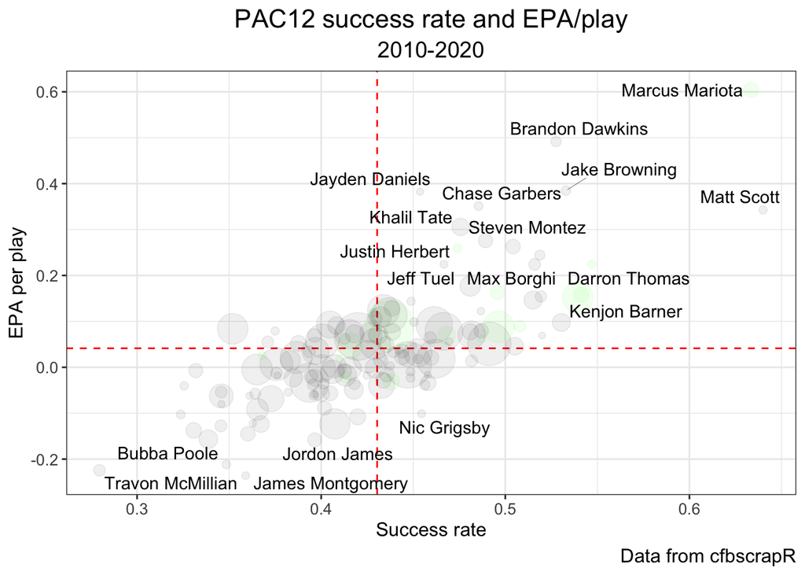

#### PAC12 Career Rush Yds vs. EPA

We can see the overall consistency of Royce Freeman and Myles Gaskin, which made for a great rivalry the years they squared off. Again, notice Marcus Mariota’s explosiveness compared to other players on the chart below.

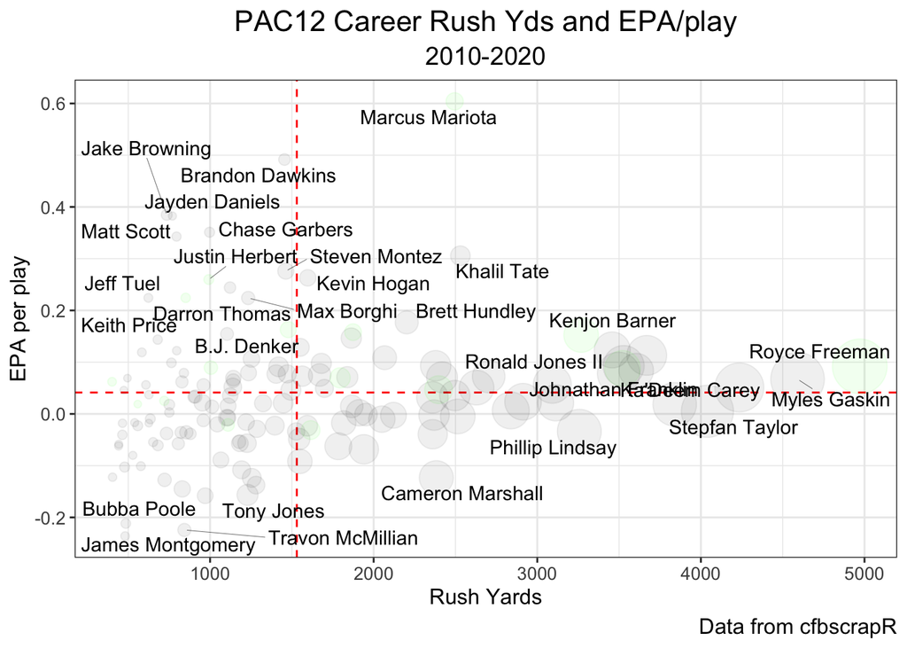